# Решения к заданиям MYTONA

[Дмитрий Пасько](https://github.com/PasaOpasen)

07.09.2020

Это моё решение тестового задания по вакансии от MYTONA. Сами задания и другие файлы расположены в репозитории: https://github.com/PasaOpasen/Garbage_code/tree/master/mytona

# Задание 1

Зафиксируем нашу систему в некоторый момент времени. Схематически она будет выглядеть как-то так:

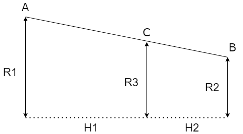

Здесь пунктирной линией изображен условный горизонт (земля), $R_1$, $R_2$ - расстояния от земли до левого и правого конца оси. Из условия задачи помним, что эти расстояния взяты из *независимых* нормальных распределений со средним $R$ и дисперсиями $n$ и $m$ соответственно.

Требуется определить положение точки **C**, на которой меньше всего трясёт (дисперсия минимальна).

Сначала выразим $R_3$ через $R_1, R_2$. Поскольку здесь прямоугольная трапеция, это можно сделать через формулу её площади:

$$S = \frac{1}{2} (R_1 + R_2) \cdot H = \frac{1}{2} (R_1 + R_3) \cdot H_1 + \frac{1}{2} (R_3 + R_2) \cdot H_2$$

Если умножить на 2 и раскрыть скобки, получим:

$$R_1H_1 + R_1H_2+R_2H_1+R_2H_2 = R_1H_1 + R_3H_1+R_3H_2+R_2H_2$$

$$R_1H_2+R_2H_1 = R_3H_1+R_3H_2$$

Известно, что $\frac{AC}{H_1} = \frac{BC}{H_2} \rightarrow \frac{AC}{BC} = \frac{H_1}{H_2}$. Поделим последнее полученное уравнение на $H_2$ и обозначим искомое соотношение за $k$:

$$k = \frac{H_1}{H_2} = \frac{AC}{BC}$$
$$R_1+R_2 \cdot k = R_3 \cdot k+R_3 \rightarrow R_3 = \frac{R_1+R_2 \cdot k}{1 + k}$$

Найдём дисперсию $R_3$, используя свойста дисперсии для независимых случайных величин:

$$D(R_3) = D(\frac{R_1+R_2 \cdot k}{1 + k}) = \frac{1}{(1+k)^2} D(R_1+R_2 \cdot k) = \frac{1}{(1+k)^2} (D(R_1)+D(R_2) \cdot k^2) = \frac{n+ k^2 m}{(1+k)^2}$$

Чтобы найти минимум этой функции, требуется найти точки экстремума (нули производной). Я сразу буду избавляться от слагаемых, которые ни на что не влияют:

$$(\frac{n+ k^2 m}{(1+k)^2} )' = \frac{2km(1+k)^2 - 2(k+1)(n+k^2m)}{(1+k)^4} = 0$$

$$2km(1+k) - 2(n+k^2m) = 0$$

$$2km + 2k^2m - 2n - 2k^2 m = 0$$

$$k = \frac{n}{m}$$

Нетрудно проверить, что это именно точка минимума.

**Ответ**: $\frac{n}{m}$

# Задание 2

Чтобы модель хотя бы начала работать для регрессии, нужно

1. Поставить функцию потерь для регрессии (вместо `categorical_crossentropy` поставить, например, `mean_squared_error`)
2. Убрать из метрик правильность (`acc`), так как это метрика для классификаторов.

Сейчас модель выдаёт два числа с суммой 1 (вероятности принадлежности к каждому из двух классов). Для осмысленной регрессии потребуется на последнем слое заменить функцию активации (например, на `relu`, но зависит от задачи) и установить один нейрон вместо двух (если требуется).

Таким образом, я бы предложил следующий код:

```
from keras.models import Sequential
from keras.layers import Dense
from keras.layers.normalization import BatchNormalization

model = Sequential()

neurons_count = 32
model.add(Dense(neurons_count, input_dim=X_train.shape[1], activation='relu'))
model.add(BatchNormalization())
model.add(Dense(1, activation='relu'))

model.compile(loss='mean_squared_error', optimizer='adam')

model.summary()
```

# Задание 3

Сразу переведём задачу на язык математики: имеется ансамбль из 5 классификаторов, каждый из которых выдаёт правильный ответ `1` со своей вероятностью. При этом каждый классификатор может иметь целый вес от `0` до ‘5’, причем сумма всех весов равна `5`. Требуется подобрать оптимальные веса (чтоб точность ансамбля была максимальной).

Решим эту задачу, проделав большое число симуляций.

Первым делом запишем вероятности:

```r
probs = c(0.8, 0.7, 0.6, 0.5, 0.3)

print(probs)
```

```
## [1] 0.8 0.7 0.6 0.5 0.3
```

Определим всевозможные конфигурации весов, подходящие условию (все комбинации 5 чисел от 0 до 5, дающих в сумме 5):

```r
library(tidyr)

facilities = 0:5
all_combs = crossing(coef1 = facilities, coef2 = facilities, coef3 = facilities,
    coef4 = facilities, coef5 = facilities)

is5 = apply(all_combs, 1, function(row) sum(row) == 5)

all_combs = all_combs[is5, ]

all_combs
```

| coef1 | coef2 | coef3 | coef4 | coef5 |
| --- | --- | --- | --- | --- |
| 0 | 0 | 0 | 0 | 5 |
| 0 | 0 | 0 | 1 | 4 |
| 0 | 0 | 0 | 2 | 3 |
| 0 | 0 | 0 | 3 | 2 |
| 0 | 0 | 0 | 4 | 1 |
| 0 | 0 | 0 | 5 | 0 |
| 0 | 0 | 1 | 0 | 4 |
| 0 | 0 | 1 | 1 | 3 |
| 0 | 0 | 1 | 2 | 2 |
| 0 | 0 | 1 | 3 | 1 |

[output cut: 116 more lines]

**Алгоритм симуляции** заключается в следующем:

1. для каждого классификатора проводим $n$ симуляций, то есть получаем $n$ случайных чисел из биномиального распределения с соответствующей вероятностью позитивного исхода
2. для каждой конфигурации весов и всех симуляций проводим суммирование голосов и находим среднее число позитивных исходов у каждой конфигурации (позитивный исход - это когда сумма ответов по ансамблю больше чем 2)
3. выбираем конфигурацию с наибольшим средним числом позитивных исходов

## Пример

Сделаем 10 симуляций с нашими классификаторами:

```r
sim_results = sapply(probs, function(p) rbinom(10, 1, p))

sim_results
```

```
##       [,1] [,2] [,3] [,4] [,5]
##  [1,]    1    1    0    0    1
##  [2,]    1    0    0    1    0
##  [3,]    0    0    0    1    1
##  [4,]    1    1    1    1    1
##  [5,]    1    1    0    1    0
##  [6,]    0    0    1    0    0
##  [7,]    1    1    0    0    0
##  [8,]    1    0    0    0    0
##  [9,]    0    1    0    0    0
## [10,]    0    1    1    0    0
```

Возьмем конфигурацию номер 67:

```r
comb = all_combs[67, ]

comb
```

| coef1 | coef2 | coef3 | coef4 | coef5 |
| --- | --- | --- | --- | --- |
| 1 | 0 | 2 | 1 | 1 |

Перемножим полученные матрицу и вектор:

```r
ans = sim_results %*% t(comb)

ans
```

```
##       [,1]
##  [1,]    2
##  [2,]    2
##  [3,]    2
##  [4,]    5
##  [5,]    2
##  [6,]    2
##  [7,]    1
##  [8,]    1
##  [9,]    0
## [10,]    2
```

Преобразуем ответ в категории правильно-неправильно:

```r
ans = ans > 2

ans
```

```
##        [,1]
##  [1,] FALSE
##  [2,] FALSE
##  [3,] FALSE
##  [4,]  TRUE
##  [5,] FALSE
##  [6,] FALSE
##  [7,] FALSE
##  [8,] FALSE
##  [9,] FALSE
## [10,] FALSE
```

Найдём среднее количество верных ответов, это и будет оценка нашей конфигурации:

```r
mean(ans)
```

```
## [1] 0.1
```

## Решение

Симуляцию выполняет следующая функция:

```r
get_best_combination = function(count) {

    sim_results = sapply(probs, function(p) rbinom(count, 1, p))


    answers = numeric(nrow(all_combs))

    for (i in 1:nrow(all_combs)) {

        comb = all_combs[i, ]

        nums = (sim_results %*% t(comb)) > 2

        answers[i] = mean(nums)

    }

    result = as.numeric(all_combs[which.max(answers), ])

    cat("best accuracy:", max(answers), "on", result, "combination\n")

    return(result)
}
```

```r
get_best_combination(10^3)
```

```
## best accuracy: 0.818 on 3 0 0 0 2 combination
```

```
## [1] 3 0 0 0 2
```

Ответ неожиданный, но я получал его много раз. Его можно объяснить тем, что раз пятый классификатор так часто ошибается, его мнение очень необычное и при некотором раскладе весов может быть полезно.

**Ответ**: 3 из первого, 2 из последнего